# Drehmoment, Drehzahl und Lufttemperatur im AI4I-Datensatz

Explorative Analyse · Aufgabe 10.4 · Freigegebene Fassung

Zusammenfassung

Diese Arbeit untersucht Verteilungen, statistisch auffällige Werte und paarweise Zusammenhänge von Drehmoment, Drehzahl und Lufttemperatur im synthetischen AI4I-Datensatz. Grundlage sind 10.000 vollständige Beobachtungen; die Zeilenkennung UDI wird nicht als Zeitvariable verwendet. Histogramme und Boxplots beschreiben die Verteilungen, ein Streudiagramm zeigt die gemeinsame Struktur von Drehmoment und Drehzahl. Pearson- und Spearman-Korrelationen ergänzen die visuelle Auswertung. Das Drehmoment ist annähernd symmetrisch, während die Drehzahl deutlich rechtsschief verteilt ist. Zwischen beiden Größen besteht ein starker negativer, gekrümmter Zusammenhang. Die Lufttemperatur weist dagegen nur geringe paarweise Korrelationen auf. IQR-Markierungen kennzeichnen ungewöhnliche Randwerte, begründen aber weder Messfehler noch deren Entfernung. Die Ergebnisse beschreiben den vorliegenden synthetischen Datensatz. Sie erlauben keine kausalen Aussagen und keine ungeprüfte Übertragung auf reale Maschinen. Der KI-gestützte Text wurde nach studentischem Review überarbeitet und am 26.10.2026 fachlich freigegeben.

# Fragestellung

Wie unterscheiden sich die Verteilungen von Drehmoment, Drehzahl und Lufttemperatur, und welche paarweisen Zusammenhänge sind in den Daten sichtbar? Diese Frage wird deskriptiv untersucht. Ziel ist eine begründete Auswahl von Darstellungen und Kennzahlen, keine Vorhersage von Maschinenausfällen. Drei Abbildungen verbinden Verteilungsform, Randwerte und gemeinsame Struktur. Eine Tabelle beziffert die Korrelationen, ohne denselben Befund zusätzlich als Heatmap zu wiederholen.

# Daten und Methoden

Verwendet wird der öffentlich verfügbare AI4I 2020 Predictive Maintenance Dataset aus dem UCI-Repositorium (*AI4I 2020 Predictive Maintenance Dataset* 2020). Er enthält synthetisch erzeugte Daten und steht unter CC BY 4.0. Aus 14 vorhandenen Spalten werden UDI, Drehmoment in Nm, Drehzahl in rpm und Lufttemperatur in K geladen. Alle 10.000 Zeilen bleiben erhalten; in diesen vier Spalten fehlen keine Werte. Die Dateiintegrität wird vor dem Laden mit einer festgelegten SHA256-Prüfsumme kontrolliert. UDI ist eine Zeilenkennung, kein Zeitstempel. Die Auswertung enthält daher keine zeitlichen Trendaussagen.

Histogramme mit jeweils 30 gleich breiten Klassen zeigen die Verteilungsform. Die Klassenbildung ist eine Darstellungsentscheidung und kein statistischer Nachweis einer bestimmten Verteilungsfamilie. Boxplots ergänzen Median, Quartile und Randwerte.

Der Interquartilsabstand ist

$$IQR = Q_{0{,}75}-Q_{0{,}25}.$$

Dabei bezeichnet $Q_p$ das empirische Quantil zum Anteil $p$, hier mit linearer Interpolation berechnet. Werte unter $Q_{0{,}25}-1{,}5\,IQR$ oder über $Q_{0{,}75}+1{,}5\,IQR$ werden markiert (NIST/SEMATECH, o. J.). Die Grenzen besitzen jeweils die Einheit der untersuchten Größe. Werte genau auf einer Grenze zählen nicht als auffällig. Eine kleine Rechentoleranz schützt exakte Grenzwerte vor Rundungsfehlern; technische Einzelheiten stehen im Begleitnotebook. Die Markierungen lösen keine Datenbereinigung aus.

Für Beobachtungspaare $(x_i,y_i)$ wird der Pearson-Koeffizient berechnet:

$$r_{xy}=\frac{\sum_{i=1}^{n}(x_i-\bar{x})(y_i-\bar{y})}
{\sqrt{\sum_{i=1}^{n}(x_i-\bar{x})^2\sum_{i=1}^{n}(y_i-\bar{y})^2}}.$$

Hier ist $n=10\,000$; $\bar{x}$ und $\bar{y}$ sind die jeweiligen arithmetischen Mittelwerte. Für Drehmoment und Drehzahl haben $x_i$ und $y_i$ die Einheiten Nm und rpm; $r_{xy}$ ist einheitenlos. Pearson misst lineare Zusammenhänge (SciPy, o. J.-a). Ergänzend wird Spearmans Rangkorrelation $\rho_s$ berechnet, also die Pearson-Korrelation der Ränge mit mittleren Rängen bei Bindungen. Sie erfasst monotone Zusammenhänge auch dann, wenn diese gekrümmt sind (SciPy, o. J.-b). Beide Maße werden als deskriptive Kennzahlen verwendet; Signifikanztests oder Konfidenzintervalle werden nicht als Nachweis einer realen Grundgesamtheit interpretiert.

# Ergebnisse

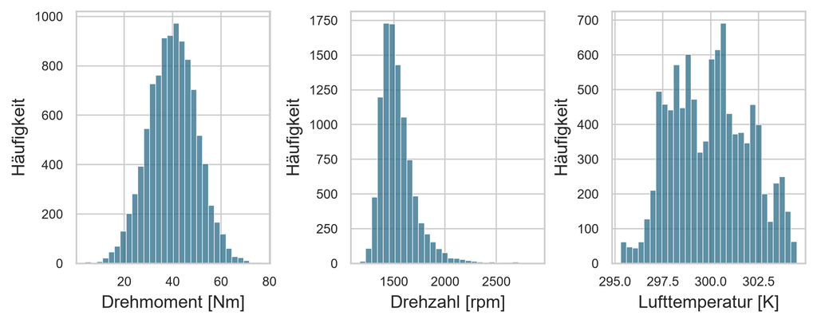

Abbildung 1: Verteilungen der drei Messgrößen (je 10.000 Werte, 30 Klassen). Die Achsen sind je Teilbild eigenständig skaliert; Balkenhöhen zeigen absolute Häufigkeiten.

Abbildung 1 zeigt für das Drehmoment eine annähernd symmetrische, glockenförmige Verteilung. Der Mittelwert beträgt 39,987 Nm, der beobachtete Bereich reicht von 3,8 bis 76,6 Nm. Das Erscheinungsbild allein beweist keine Normalverteilung. Die Drehzahl besitzt einen deutlich längeren rechten Rand; hohe Drehzahlen kommen seltener vor. Die Lufttemperatur zeigt eine unregelmäßige Häufigkeitsstruktur. Eine geringe Schiefe würde hier nicht genügen, um eine Normalverteilung anzunehmen, da Schiefe weder Mehrgipfligkeit noch lokale Häufungen vollständig beschreibt.

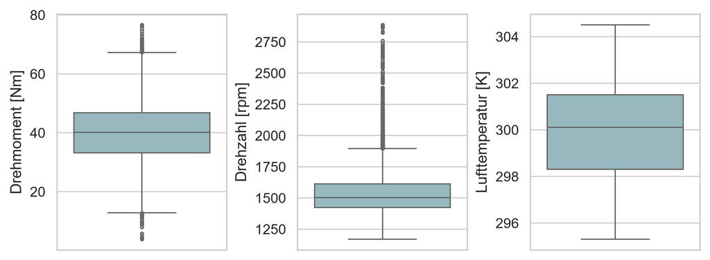

Abbildung 2: Boxplots mit Median, mittleren 50 Prozent und 1,5-IQR-Regel. Einzelpunkte außerhalb der Whisker bleiben Bestandteil der Analyse; überlagerte Punkte sind nicht einzeln abzählbar.

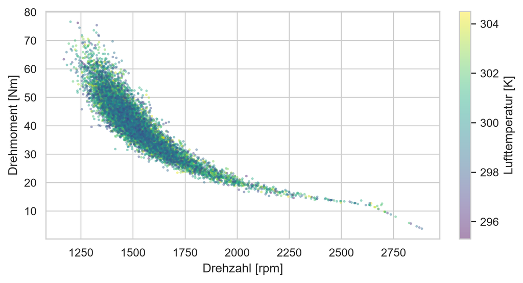

Abbildung 3: Drehmoment und Drehzahl für sämtliche 10.000 Beobachtungen. Transparenz vermindert Überdeckung, die Farbe kodiert die Lufttemperatur in K; es erfolgt keine Stichprobenauswahl.

Abbildung 3 zeigt einen ausgeprägten negativen Zusammenhang: Größere Drehzahlen gehen im Datensatz überwiegend mit geringerem Drehmoment einher. Die Punktwolke verläuft gekrümmt und hat eine erkennbare Streuung. Eine einzelne Gerade würde diese Form nur unvollständig beschreiben. Die Temperaturfarben überlagern sich weitgehend; eine klare Trennung nach Lufttemperatur ist in dieser Projektion nicht erkennbar. Dichtebereiche können trotz Transparenz einzelne Beobachtungen verdecken.

Tabelle 1: Pearson- und Spearman-Korrelationen der drei Messgrößen; vier Nachkommastellen, n = 10.000.

| Größenpaar | Pearson $r$ | Spearman $\rho_s$ |
| --- | --- | --- |
| Drehmoment / Drehzahl | -0,8750 | -0,9165 |
| Drehmoment / Lufttemperatur | -0,0138 | -0,0118 |
| Drehzahl / Lufttemperatur | 0,0227 | 0,0137 |

Die Kennzahlen in Tabelle 1 stützen den visuellen Befund. Für Drehmoment und Drehzahl ist Pearson mit $r=-0{,}8750$ stark negativ. Spearman fällt mit $\rho_s=-0{,}9165$ im Betrag noch größer aus. Dies passt zu einem überwiegend monotonen, aber nicht streng linearen Zusammenhang. Die Differenz der beiden Kennzahlen allein ist allerdings kein Test auf Nichtlinearität; die Interpretation beruht auch auf der Punktwolke. Die Pearson-Korrelationen mit der Lufttemperatur sind mit $-0{,}0138$ für Drehmoment und $0{,}0227$ für Drehzahl gering. Auch die Rangkorrelationen liegen nahe null. Daraus folgt keine statistische Unabhängigkeit: Andere nichtmonotone, bedingte oder mehrdimensionale Beziehungen bleiben möglich.

# Diskussion und Grenzen

Die Kombination der Darstellungen ist informativer als eine isolierte Korrelationszahl. Histogramme zeigen Formunterschiede, Boxplots machen die IQR-Regel nachvollziehbar, und das Streudiagramm zeigt die Krümmung hinter dem starken negativen Koeffizienten. Deshalb werden weder weitere Varianten derselben Verteilungsdarstellung noch eine zusätzliche Korrelationsheatmap in den kurzen Bericht aufgenommen. Die vollständige EDA bleibt im begleitenden Notebook erhalten.

Der synthetische Ursprung ist die wesentliche Einschränkung. Das UCI-Repositorium beschreibt ausdrücklich die Erzeugungsregeln der Variablen, unter anderem eine Kopplung der Drehzahl an eine vorgegebene Leistung (*AI4I 2020 Predictive Maintenance Dataset* 2020). Die beobachtete Struktur darf daher nicht als unabhängig entdecktes Naturgesetz oder als Bestätigung eines realen Maschinenmechanismus dargestellt werden. Diese Quelleninformation erklärt die Konstruktion des Datensatzes; die vorliegende Analyse selbst identifiziert keine Ursache. Für reale Anlagen wären Herkunft, Messverfahren, Betriebszustände und mögliche Störgrößen gesondert zu prüfen.

Ebenso wenig sind die IQR-Markierungen diagnostizierte Fehler oder Ausfälle. Die hier betrachteten vier Spalten enthalten keine Auswertung der vorhandenen Ausfallkennzeichen. Ein Zusammenhang zwischen Randwerten und tatsächlichen Ausfällen wird daher nicht untersucht. Das Beibehalten aller Beobachtungen verhindert eine nachträgliche Verengung der Verteilungen durch unbegründetes Entfernen gerade jener Werte, die beschrieben werden sollen.

Weitere Grenzen liegen in der Klassenwahl der Histogramme und der Überdeckung im Streudiagramm. Drei ausgewählte Messgrößen bilden außerdem nicht sämtliche Variablen des Datensatzes ab. Es werden weder zeitliche Dynamiken noch Vorhersagegüte oder Übertragbarkeit geprüft. Die große Zeilenzahl ersetzt keine repräsentative Stichprobe realer Maschinen und garantiert keine unabhängigen Beobachtungen. Die Aussagen bleiben deshalb auf die beschriebenen Daten und Methoden begrenzt.

# Fazit

Die EDA zeigt eine rechtsschiefe Drehzahlverteilung und einen starken negativen, gekrümmten Zusammenhang zwischen Drehzahl und Drehmoment. Die Lufttemperatur besitzt nur geringe paarweise lineare und monotone Korrelationen mit beiden Größen. IQR-Markierungen beschreiben Randwerte, ohne ihre Ursache zu bestimmen. Für eine belastbare Anwendung außerhalb dieses synthetischen Datensatzes wären zusätzliche reale Daten und eine eigenständige Validierung erforderlich.

# Transparenz und Reproduzierbarkeit

**APPROVED (26.10.2026).** Codex erstellte den Entwurf und setzte die Korrekturwünsche aus zwei studentischen PDF-Reviews um. Der Studierende hat die wissenschaftlichen Inhalte am 26.10.2026 ausdrücklich freigegeben. KI-Beiträge und technische Prüfungen sind im Projektprotokoll getrennt von den unveränderten studentischen Reviews dokumentiert.

Berechnungen erfolgen mit den gesperrten Python-Abhängigkeiten des Projekts. Der Bericht lädt die Originaldaten über die geprüfte Ladefunktion aus 10.2 und verwendet die IQR-Methode aus 10.3. Quarto führt die QMD aus und erzeugt HTML sowie PDF über LuaLaTeX. Das begleitende Notebook macht den vollständigen Analyseweg zugänglich. Ein Beispiel für einklappbaren Code steht ausschließlich in der HTML-Fassung; im PDF bleibt der Code verborgen.

**Datenprüfung und Mittelwert nachvollziehen**

```python
assert data.shape == (10000, 4)
assert not data.isna().any().any()
print(f"Mittleres Drehmoment: {data['Torque [Nm]'].mean():.5f} Nm")
```

```
Mittleres Drehmoment: 39.98691 Nm
```

# Literatur

*AI4I 2020 Predictive Maintenance Dataset*. 2020. UCI Machine Learning Repository. https://doi.org/10.24432/C5HS5C.

NIST/SEMATECH. o. J. *e-Handbook of Statistical Methods: Box Plot, Abschnitt 1.3.3.7*. https://www.itl.nist.gov/div898/handbook/eda/section3/boxplot.htm.

SciPy. o. J.-a. *scipy.stats.pearsonr: Reference Documentation*. https://docs.scipy.org/doc/scipy/reference/generated/scipy.stats.pearsonr.html.

SciPy. o. J.-b. *scipy.stats.spearmanr: Reference Documentation*. https://docs.scipy.org/doc/scipy/reference/generated/scipy.stats.spearmanr.html.